# Tutorial Python 01

## Librerias

Existen distintas formas de importar librerias a Python:

- import math as m
- from math import *

La primer forma obliga a usar el alias para utilizar las funciones, por eso es más clara. Ej. *m.factorial()*

- **NumPy** stands for Numerical Python. The most powerful feature of NumPy is n-dimensional array. This library also contains basic linear algebra functions, Fourier transforms, advanced random number capabilities and tools for integration with other low level languages like Fortran, C and C++
- **SciPy** stands for Scientific Python. SciPy is built on NumPy. It is one of the most useful library for variety of high level science and engineering modules like discrete Fourier transform, Linear Algebra, Optimization and Sparse matrices.
- **Matplotlib** for plotting vast variety of graphs, starting from histograms to line plots to heat plots.. You can use Pylab feature in ipython notebook (ipython notebook –pylab = inline) to use these plotting features inline. If you ignore the inline option, then pylab converts ipython environment to an environment, very similar to Matlab. You can also use Latex commands to add math to your plot.
- **Pandas** for structured data operations and manipulations. It is extensively used for data munging and preparation. Pandas were added relatively recently to Python and have been instrumental in boosting Python’s usage in data scientist community.
- **Scikit Learn** for machine learning. Built on NumPy, SciPy and matplotlib, this library contains a lot of effiecient tools for machine learning and statistical modeling including classification, regression, clustering and dimensionality reduction.
- **Statsmodels** for statistical modeling. Statsmodels is a Python module that allows users to explore data, estimate statistical models, and perform statistical tests. An extensive list of descriptive statistics, statistical tests, plotting functions, and result statistics are available for different types of data and each estimator.
- **Seaborn** for statistical data visualization. Seaborn is a library for making attractive and informative statistical graphics in Python. It is based on matplotlib. Seaborn aims to make visualization a central part of exploring and understanding data.
- **Bokeh** for creating interactive plots, dashboards and data applications on modern web-browsers. It empowers the user to generate elegant and concise graphics in the style of D3.js. Moreover, it has the capability of high-performance interactivity over very large or streaming datasets.
- **Blaze** for extending the capability of Numpy and Pandas to distributed and streaming datasets. It can be used to access data from a multitude of sources including Bcolz, MongoDB, SQLAlchemy, Apache Spark, PyTables, etc. Together with Bokeh, Blaze can act as a very powerful tool for creating effective visualizations and dashboards on huge chunks of data.
- **Scrapy** for web crawling. It is a very useful framework for getting specific patterns of data. It has the capability to start at a website home url and then dig through web-pages within the website to gather information.
- **SymPy** for symbolic computation. It has wide-ranging capabilities from basic symbolic arithmetic to calculus, algebra, discrete mathematics and quantum physics. Another useful feature is the capability of formatting the result of the computations as LaTeX code.
- **Requests** for accessing the web. It works similar to the the standard python library urllib2 but is much easier to code. You will find subtle differences with urllib2 but for beginners, Requests might be more convenient.

Otras librerias útiles:

- **os** for Operating system and file operations
- **networkx** and **igraph** for graph based data manipulations
- **regular expressions** for finding patterns in text data
- **BeautifulSoup** for scrapping web. It is inferior to Scrapy as it will extract information from just a single webpage in a run.

## Análisis exploratorio de datos usando **Pandas**

Pandas usa dos tipo de datos fundamentales: Series y DataFrames.

Tutoriales sobre Pandas:

- **[*10 Minutes to pandas*](http://pandas.pydata.org/pandas-docs/stable/10min.html)**
- **[*12 Useful Pandas Techniques in Python for Data Manipulation*](https://www.analyticsvidhya.com/blog/2016/01/12-pandas-techniques-python-data-manipulation/)**

### Introducción a Series y Dataframes

**Series**: Array de una dimensión con nombres. Se puede acceder a los elementos a través de esos nombres.

**Dataframe**: Columnas con nombres y filas a las que se puede acceder a través del nro de fila.

Estos dos tipos de datos forman el núcleo de lo que es Pandas. Los data sets son leidos a estos dataframes a los que, luego, se les puede aplicar operaciones varias como agupamientos o agregaciones.

## Exploración de datos

```python
#Please use `%pylab inline` or `%matplotlib inline` in the notebook itself.
%pylab inline
%matplotlib inline

import pandas as pd
import numpy as np
import matplotlib as plt
```

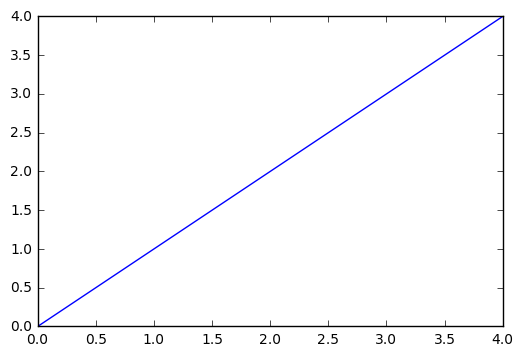

```python
plt.pyplot.plot(arange(5))
```

```python
#Reading the dataset in a dataframe using Pandas
df = pd.read_csv("C:/Users/F/Dropbox/Personal/CienciaDeDatos/98_Miscelaneos/pydata101/TutorialPython/datasets/train.csv")

df.head(10)
```

|  | Loan_ID | Gender | Married | Dependents | Education | Self_Employed | ApplicantIncome | CoapplicantIncome | LoanAmount | Loan_Amount_Term | Credit_History | Property_Area | Loan_Status |
| --- | --- | --- | --- | --- | --- | --- | --- | --- | --- | --- | --- | --- | --- |
| 0 | LP001002 | Male | No | 0 | Graduate | No | 5849 | 0.0 | NaN | 360.0 | 1.0 | Urban | Y |
| 1 | LP001003 | Male | Yes | 1 | Graduate | No | 4583 | 1508.0 | 128.0 | 360.0 | 1.0 | Rural | N |
| 2 | LP001005 | Male | Yes | 0 | Graduate | Yes | 3000 | 0.0 | 66.0 | 360.0 | 1.0 | Urban | Y |
| 3 | LP001006 | Male | Yes | 0 | Not Graduate | No | 2583 | 2358.0 | 120.0 | 360.0 | 1.0 | Urban | Y |
| 4 | LP001008 | Male | No | 0 | Graduate | No | 6000 | 0.0 | 141.0 | 360.0 | 1.0 | Urban | Y |
| 5 | LP001011 | Male | Yes | 2 | Graduate | Yes | 5417 | 4196.0 | 267.0 | 360.0 | 1.0 | Urban | Y |
| 6 | LP001013 | Male | Yes | 0 | Not Graduate | No | 2333 | 1516.0 | 95.0 | 360.0 | 1.0 | Urban | Y |
| 7 | LP001014 | Male | Yes | 3+ | Graduate | No | 3036 | 2504.0 | 158.0 | 360.0 | 0.0 | Semiurban | N |
| 8 | LP001018 | Male | Yes | 2 | Graduate | No | 4006 | 1526.0 | 168.0 | 360.0 | 1.0 | Urban | Y |
| 9 | LP001020 | Male | Yes | 1 | Graduate | No | 12841 | 10968.0 | 349.0 | 360.0 | 1.0 | Semiurban | N |

```python
df.describe()  #Summary de las variables numéricas.
```

|  | ApplicantIncome | CoapplicantIncome | LoanAmount | Loan_Amount_Term | Credit_History |
| --- | --- | --- | --- | --- | --- |
| count | 614.000000 | 614.000000 | 592.000000 | 600.00000 | 564.000000 |
| mean | 5403.459283 | 1621.245798 | 146.412162 | 342.00000 | 0.842199 |
| std | 6109.041673 | 2926.248369 | 85.587325 | 65.12041 | 0.364878 |
| min | 150.000000 | 0.000000 | 9.000000 | 12.00000 | 0.000000 |
| 25% | 2877.500000 | 0.000000 | 100.000000 | 360.00000 | 1.000000 |
| 50% | 3812.500000 | 1188.500000 | 128.000000 | 360.00000 | 1.000000 |
| 75% | 5795.000000 | 2297.250000 | 168.000000 | 360.00000 | 1.000000 |
| max | 81000.000000 | 41667.000000 | 700.000000 | 480.00000 | 1.000000 |

```python
# pd.show_versions()            #Saber las versiones
#df.describe(include=['category'])      #Descripción de variables categóricas NO ANDUVO - VER
df.describe(exclude=[np.number])        #Excluir variables numericas, entonces describe solo las categóricas.
```

|  | Loan_ID | Gender | Married | Dependents | Education | Self_Employed | Property_Area | Loan_Status |
| --- | --- | --- | --- | --- | --- | --- | --- | --- |
| count | 614 | 601 | 611 | 599 | 614 | 582 | 614 | 614 |
| unique | 614 | 2 | 2 | 4 | 2 | 2 | 3 | 2 |
| top | LP001749 | Male | Yes | 0 | Graduate | No | Semiurban | Y |
| freq | 1 | 489 | 398 | 345 | 480 | 500 | 233 | 422 |

```python
df['Property_Area'].value_counts()      #Contar una columna en especial
```

```
Semiurban    233
Urban        202
Rural        179
Name: Property_Area, dtype: int64
```

## Análisis de distribución

Como ejemplo se mostrará la distribución de dos variables numéricas ApplicantIncome and LoanAmount

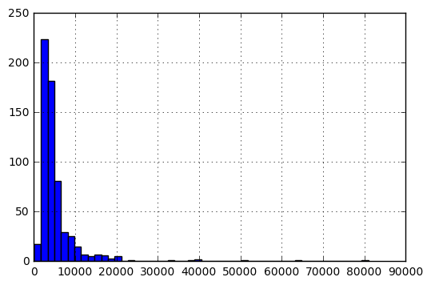

```python
df['ApplicantIncome'].hist(bins=50)
```

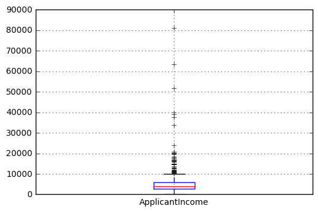

```python
df.boxplot(column='ApplicantIncome')
```

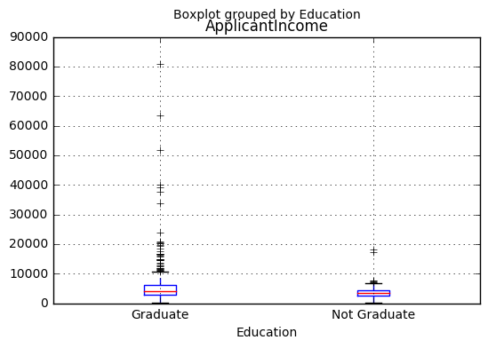

```python
df.boxplot(column='ApplicantIncome', by = 'Education')  #Agrupando por educación
```

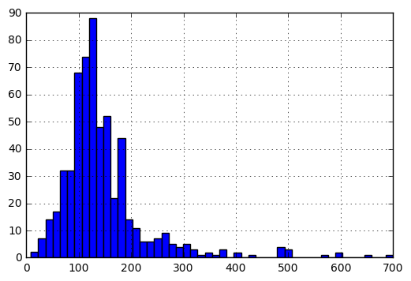

```python
df['LoanAmount'].hist(bins=50)
```

## Variables categóricas

Ver las técnicas utilizadas en este tutorial: **[*12 Useful Pandas Techniques in Python for Data Manipulation*](https://www.analyticsvidhya.com/blog/2016/01/12-pandas-techniques-python-data-manipulation/)**

```python
temp1 = df['Credit_History'].value_counts(ascending=True)
print ('Frequency Table for Credit History:')
print (temp1)

# Pivot table como en Excel
temp2 = df.pivot_table(values='Loan_Status',index=['Credit_History'],aggfunc=lambda x: x.map({'Y':1,'N':0}).mean())
print ('\nProbility of getting loan for each Credit History class:')
print (temp2)
```

```
Frequency Table for Credit History:
0.0     89
1.0    475
Name: Credit_History, dtype: int64

Probility of getting loan for each Credit History class:
                Loan_Status
Credit_History
0.0                0.078652
1.0                0.795789
```

[figure not shown]

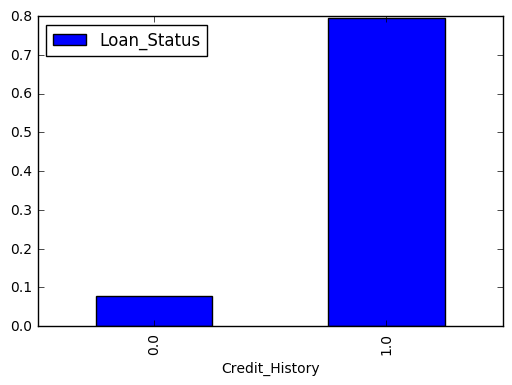

```python
# Gráfico de barras usando matplotlib
import matplotlib.pyplot as plt
fig = plt.figure(figsize=(8,4))
ax1 = fig.add_subplot(121)
ax1.set_xlabel('Credit_History')
ax1.set_ylabel('Count of Applicants')
ax1.set_title("Applicants by Credit_History")
temp1.plot(kind='bar')

ax2 = fig.add_subplot(122)
temp2.plot(kind = 'bar')
ax2.set_xlabel('Credit_History')
ax2.set_ylabel('Probability of getting loan')
ax2.set_title("Probability of getting loan by credit history")
```

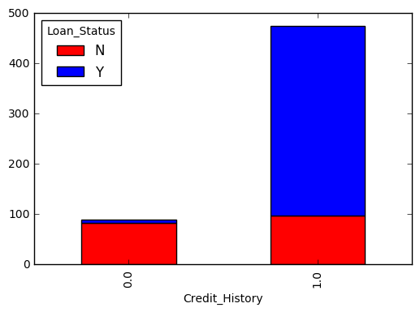

```python
# Stacked bar
temp3 = pd.crosstab(df['Credit_History'], df['Loan_Status'])
temp3.plot(kind='bar', stacked=True, color=['red','blue'], grid=False)
```

# Data munging (data manipulation) in Python

Ver **[Data Munging in Python (using Pandas)](https://www.analyticsvidhya.com/blog/2014/09/data-munging-python-using-pandas-baby-steps-python/)**

Data munging ==> Acondicionar o preparar los datos para su análisi posterior.

En los datos previos se obseraron lo siguientes problemas:

# 1 **Valores faltantes** (missing values) in algunas variables. Hay que estimar esos valores dependiendo en la cantidad de valores faltantes y la importancia esperada de esas variables.

# 2 **Outliers** Observando los valores de las variables *ApplicantIncome y LoanAmount* parecen observarse valores extremos.

## Buscando valores faltantes en el dataset

```python
df.apply(lambda x: sum(x.isnull(),axis=0))
```

```
Loan_ID               0
Gender               13
Married               3
Dependents           15
Education             0
Self_Employed        32
ApplicantIncome       0
CoapplicantIncome     0
LoanAmount           22
Loan_Amount_Term     14
Credit_History       50
Property_Area         0
Loan_Status           0
dtype: int64
```

```python
#Reemplazando faltantes por la media en 'LoanAmount' utilizando la func 'fillna'
df['LoanAmount'].fillna(df['LoanAmount'].mean(), inplace=True)
df.apply(lambda x: sum(x.isnull(),axis=0))['LoanAmount']       #Verificamos cuantos NULL quedaron en LoanAmount
```

```
0
```

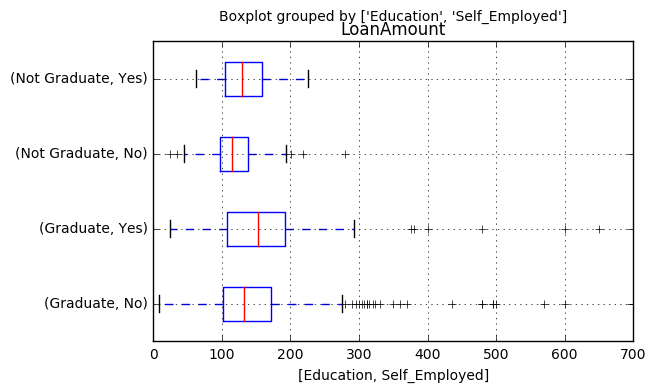

```python
df.boxplot(column='LoanAmount', by = ['Education', 'Self_Employed'], vert=False)
```

```python
#Self_Employed tiene algunos valores faltantes.
df['Self_Employed'].value_counts()
```

```
No     500
Yes     82
Name: Self_Employed, dtype: int64
```

```python
df.apply(lambda x: sum(x.isnull(),axis=0))['Self_Employed']  #Cuento la cantidad NAs antes
```

```
32
```

```python
#Como hay muchos más valores en NO que, lo más seguro es asignar NO a los valores faltantes. (este es el criterio adoptado por el tutorial)
df['Self_Employed'].fillna('No',inplace=True)
df.apply(lambda x: sum(x.isnull(),axis=0))['Self_Employed'] #Cuento la cantidad NAs despues
```

```
0
```

Siguiendo con el tutorial, ahora se creara una Pivot Table que indique la mediana para todos los grupos de 'Self_employed' y 'Education'.

Luego se definirá una función que devolverá los valores de las celdas para aplicar a los valores faltantes de loan mount

```python
table = df.pivot_table(values='LoanAmount', index='Self_Employed' ,columns='Education', aggfunc=np.median)
```

```python
# Define function to return value of this pivot_table
def fage(x):
 return table.loc[x['Self_Employed'],x['Education']]
```

```python
# Replace missing values
df['LoanAmount'].fillna(df[df['LoanAmount'].isnull()].apply(fage, axis=1), inplace=True)  #Esto falla, habría que ver porque.
```

[output not shown]

# Como manejar valores extremos en las columnas LoanAmount y ApplicantIncome

Se aplica un logaritmo a los valores para unificar los extremos y no manejarlos como outliers.

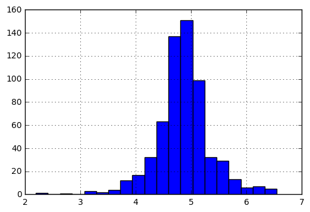

```python
df['LoanAmount_log'] = np.log(df['LoanAmount'])
df['LoanAmount_log'].hist(bins=20)
```

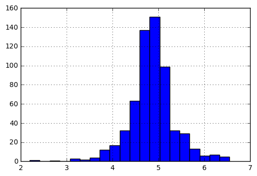

```python
#Algo similar con ApplicantIncome

df['TotalIncome'] = df['ApplicantIncome'] + df['CoapplicantIncome']
df['TotalIncome_log'] = np.log(df['TotalIncome'])
df['LoanAmount_log'].hist(bins=20)
```

# Consturyendo un modelo predictivo en Python

Librería más usada en Py para ML: **Skicit-Learn (sklearn)**

Ver más información sobre [sklearn](https://www.analyticsvidhya.com/blog/2015/01/scikit-learn-python-machine-learning-tool/)

**Sklearn requiere que todas sus entradas sean numéricas**. Por lo tanto habrá que convertir las variables categóricas en numéricas codificando las categorías.

```python
from sklearn.preprocessing import LabelEncoder
```

```python
var_mod = ['Gender','Married','Dependents','Education','Self_Employed','Property_Area','Loan_Status']
#le = LabelEncoder()
for i in var_mod:
    df[i] = LabelEncoder().fit_transform(df[i])
df.dtypes
```

[output not shown]